# workshop

2022-08-24

```r
library(tidyverse)
```

```r
library(ggplot2)
library(QFeatures)
library(msqrob2)
```

# Introduction

This part of the workshop will focus on the data analysis pipeline that comes after the search engine from quantification to differential expression analysis. The pipeline is designed to work with ionbot output, but is of course only one example. Different parts of the pipeline can be interchanged for other pieces of software as desired.

We will work with the same dataset as in the first part of the workshop. In the paper, the authors worked with archeological samples and with modern samples (dental calculus and plaque). Here, we will try and see whether we can find any proteins that are differentially expressed between those groups.

# Quantification with FlashLFQ

FlashLFQ is a high-speed label-free quantification algorithm. It was developed by Millikin et al. at the university of Wisconsin. In future releases of ionbot, the user will be able to ask for flashLFQ input directly from the ionbot search engine, making it easier to go straight to the quantification step. For now, we will provide you with the FlashLFQ input file based on the ionbot search results. For details on how this was done, see: https://github.com/sdgroeve/ionbot.quant

FlashLFQ has a GUI, can be run from the command line, has a docker image and can be installed via bioconda (which we have done here). You can run FlashLFQ command line from within an RMarkDown file by adding a bash chunk. To run it on Linux, you need .NET core. To see all the arguments, run the help parameter.

```bash
FlashLFQ --help
```

```
## FlashLFQ 1.2.4.294
##
##   --idt        Required. string; identification file path
##   --rep        Required. string; directory containing spectral data files
##   --sil        (Default: false) bool; silent mode
##   --rea        (Default: false) bool; filesystem is readonly, prevents writing
##                to the FlashLFQ folder
##   --pth        (Default: false) bool; print Thermo's RawFileReader licence;
##                required to read .raw files
##   --ath        (Default: false) bool; accept Thermo's RawFileReader licence;
##                required to read .raw files
##   --out        string; output directory
##   --nor        (Default: false) bool; normalize intensity results
##   --ppm        (Default: 10) double; ppm tolerance
##   --iso        (Default: 5) double; isotopic distribution tolerance in ppm
##   --int        (Default: false) bool; integrate peak areas (not recommended)
##   --nis        (Default: 2) int; number of isotopes required to be observed
##   --chg        (Default: false) bool; use only precursor charge state
##   --thr        (Default: -1) int; number of CPU threads to use
##   --mbr        (Default: false) bool; match between runs
##   --mrt        (Default: 2.5) double; maximum MBR window in minutes
##   --rmc        (Default: false) bool; require MS/MS ID in condition
##   --bay        (Default: false) bool; Bayesian protein fold-change analysis
##   --ctr        string; control condition for Bayesian protein fold-change
##                analysis
##   --fcc        (Default: 0.1) double; fold-change cutoff for Bayesian protein
##                fold-change analysis
##   --mcm        (Default: 3000) int; number of markov-chain monte carlo
##                iterations for the Bayesian protein fold-change analysis
##   --bur        (Default: 1000) int; number of markov-chain monte carlo burn-in
##                iterations
##   --sha        (Default: false) bool; use shared peptides for protein
##                quantification
##   --rns        int; random seed for the Bayesian protein fold-change analysis
##   --help       Display this help screen.
##   --version    Display version information.
```

Let’s keep it simple for now and try to quantify 2 files from the project. You can find the file containing the id input data under /Data_part2 and the RAW files under /Data_part2/RAW/.

There are multiple parameters that you can change the arguments for (see above). You need to specify the identification file(s) and the spectrum files. If you work with Thermo Raw files you also need to accept their license (parameter -ath). You can also add an output directory and choose if you want match between runs enabled. Let’s try this out now!

```bash
FlashLFQ --idt ~/Data_part2/flashlfq_input_.tsv --rep ~/Data_part2/RAW/ --out ~/FlashLFQ_out/ --ppm 5 --mbr --ath
```

```
## Opening PSM file /home/jovyan/Data_part2/flashlfq_input_.tsv
## Done reading PSMs; found 23271
## Setup is OK; read in 23271 identifications; starting FlashLFQ engine
## Reading spectra file
## Indexing MS1 peaks
## Quantifying peptides for 20160531_QE5_nLC14_RJC_COLLAB_GeoG_1002_01
## Checking errors
## Finished 20160531_QE5_nLC14_RJC_COLLAB_GeoG_1002_01
## Reading spectra file
## Indexing MS1 peaks
## Quantifying peptides for 20160531_QE5_nLC14_RJC_COLLAB_GeoG_988_01
## Checking errors
## Finished 20160531_QE5_nLC14_RJC_COLLAB_GeoG_988_01
## Doing match-between-runs for 20160531_QE5_nLC14_RJC_COLLAB_GeoG_1002_01
## Checking errors
## Finished MBR for 20160531_QE5_nLC14_RJC_COLLAB_GeoG_1002_01
## Doing match-between-runs for 20160531_QE5_nLC14_RJC_COLLAB_GeoG_988_01
## Checking errors
## Finished MBR for 20160531_QE5_nLC14_RJC_COLLAB_GeoG_988_01
## Done quantifying
## Analysis time: 0h 1m 9s
## Writing output...
## Finished writing output
```

While this is running you can find a small explanation of how FlashLFQ works below. See also their GitHub wiki page: https://github.com/smith-chem-wisc/FlashLFQ/wiki/ and their paper: https://doi.org/10.1021/acs.jproteome.7b00608

In MS-based proteomics experiments, there are two distinct ways of quantification: label-based and label-free. In label-based quantification stable isotope labels are incorporated into peptides. The mass spectrometer can recognise the mass difference between the labeled and unlabeled versions of a peptide, which is used to compare their respective signal intensities. In label-free quantification the MS1 ion intensity is used as a proxy for the peptide concentration in the sample. Here, we focus on label-free quantification.

To be able to use the MS1 ion intensity as a proxy for peptide abundance, we need software that is able to detect the MS1 peaks and read out their intensity.

FlashLFQ detects and quantifies chromatographic peaks and reports either apex or integrated intensity of each peak. It tries to improve on existing LFQ algorithms by making use of indexing, a method to categorize information into lookup-tables based on its properties, to drastically increase the speed of such algorithms. The indexing approach results in rapid chromatographic peak detection by storing each MS1 peak in the lookup-table according to its m/z if it matches an identification’s m/z. The latter of course means that the MS2 spectra must have already been searched by a search engine.

Go to the output directory you specified, which outputs do you find?

In this workflow, we choose to work with the peptides file, because the robust based summarisation that we will use (see below) oftentimes has superior performance to other summarisation based methods. We have already done the quantification for the entire project for you.

# Lowest Common Ancestor calculation with UniPept (optional step)

https://unipept.ugent.be/ https://doi.org/10.1021/acs.jproteome.8b00716

At the end of the data analysis pipeline you might want to assess from which bacterial species the differential proteins (if any) originate. To identify which peptides belong to which taxa, we will use UniPept. Unipept is an open source web application developed at Ghent University that is designed for metaproteomics data analysis with a focus on interactive datavisualizations. Unipept is powered by an index containing all UniProt entries, a tweaked version of the NCBI taxonomy and a custom lowest common ancestor algorithm. This combination enables a blazingly fast biodiversity analysis of large and complex metaproteome samples. The UniPept functionality can be accessed via an API, a desktop app, the website and a set of command line tools.

To get you acquainted with UniPept, we will go to the website and analyse a small set of peptides. You can find the small set of peptides in the following file: /Data_part2/peptidesUniPept.txt

Go to the website (https://unipept.ugent.be/), click on the tab “Metaproteomics Analysis” and copy-paste the peptides under Peptide list. Add the dataset to selected datasets and click search. You can explore the output after a few seconds.

# Data analysis with QFeatures and msqrob2

We will now start with the data analysis. First we will import the data into R, then do some preprocessing, then summarise to the protein level and then do the actual modelling, inference and differential abundance analysis. For this pipeline we will make us of (amongst others) two dedicated R packages: QFeatures and msqrob2.

You can find more information via the links below:

msqrob papers:

- https://doi.org/10.1074/mcp.M115.055897
- https://doi.org/10.1016/j.jprot.2017.04.004
- https://doi.org/10.1074/mcp.RA119.001624
- https://doi.org/10.1021/acs.analchem.9b04375

QFeatures package:

https://github.com/rformassspectrometry/QFeatures

## Import the data in R

### Data infrastructure

QFeatures: http://bioconductor.org/packages/release/bioc/html/QFeatures.html

We use the `QFeatures` package that provides the infrastructure to - store,  
- process, - manipulate and - analyse quantitative data/features from mass spectrometry experiments.

It is based on the `SummarizedExperiment` and `MultiAssayExperiment` classes.

Assays in a QFeatures object have a hierarchical relation:

- proteins are composed of peptides,
- themselves produced by spectra
- relations between assays are tracked and recorded throughout data processing

You can find a visual representation of a QFeatures object and the aggregative relation between different assays below

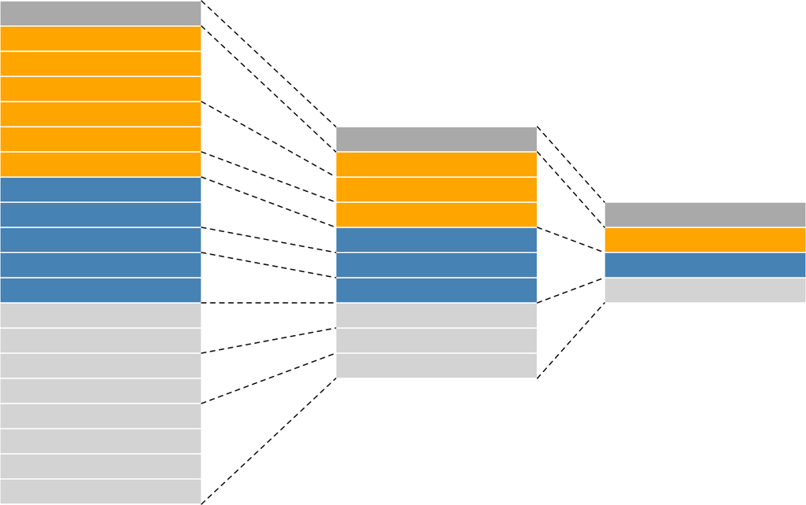

Representation of a QFeatures object and the aggregative relation between different assays

1. We use the QuantifiedPeptides.tsv file from MS-data quantified with FlashLFQ that contains MS1 intensities summarized at the peptide level. This file is for the entire dataset and already contains the UniPept LCA annotations.

```r
peptidesFile <- "~/Data_part2/QuantifiedPeptidesUniPept.tsv"
```

2. The QFeatures object needs to know where the intensity columns reside within the peptidesFile. A lot of LFQ algorithms store the intensity data for the different samples in columnns that start with/contain Intensity. We can use this to retreive the column names with the intensity data with the code below:

```r
ecols <- grep("Intensity", names(read.delim(peptidesFile)))
```

3. Read the data and store it in a QFeatures object

```r
pe <- readQFeatures(
  table = peptidesFile,
  #column to be used as feature names
  fnames = 1,
  #Here we give the information about the intensity columns
  ecol = ecols,
  name = "peptideRaw", sep="\t")
```

### Explore object

The rowData contains information on the features (peptidoforms) in the assay. E.g. Sequence, protein, …

```r
head(rowData(pe[["peptideRaw"]]))
```

```
## DataFrame with 6 rows and 22 columns
##                                                                         Sequence
##                                                                      <character>
## AAAAAAAAAAAGKnan                                                   AAAAAAAAAA...
## AAAAAAAIQAKnan                                                     AAAAAAAIQA...
## AAAAAAAIQAKSDEKnan                                                 AAAAAAAIQA...
## AAAAAAAPGTR10|[34]Methyl[T]                                        AAAAAAAPGT...
## AAAAAAGAGPEMVR0|[1]Acetyl|11|[27]Pyro_glu[E]|10|[1922]Pro->HAVA[P] AAAAAAGAGP...
## AAAAAAGDKDKVEGYIEDIVK10|[34]Methyl[D]                              AAAAAAGDKD...
##                                                                    Base.Sequence
##                                                                      <character>
## AAAAAAAAAAAGKnan                                                   AAAAAAAAAA...
## AAAAAAAIQAKnan                                                     AAAAAAAIQA...
## AAAAAAAIQAKSDEKnan                                                 AAAAAAAIQA...
## AAAAAAAPGTR10|[34]Methyl[T]                                        AAAAAAAPGT...
## AAAAAAGAGPEMVR0|[1]Acetyl|11|[27]Pyro_glu[E]|10|[1922]Pro->HAVA[P] AAAAAAGAGP...
## AAAAAAGDKDKVEGYIEDIVK10|[34]Methyl[D]                              AAAAAAGDKD...
##                                                                    Protein.Groups
##                                                                       <character>
## AAAAAAAAAAAGKnan
## AAAAAAAIQAKnan
## AAAAAAAIQAKSDEKnan
## AAAAAAAPGTR10|[34]Methyl[T]
## AAAAAAGAGPEMVR0|[1]Acetyl|11|[27]Pyro_glu[E]|10|[1922]Pro->HAVA[P]
## AAAAAAGDKDKVEGYIEDIVK10|[34]Methyl[D]                               WP_0449785...
##                                                                    Gene.Names
##                                                                     <logical>
## AAAAAAAAAAAGKnan                                                           NA
## AAAAAAAIQAKnan                                                             NA
## AAAAAAAIQAKSDEKnan                                                         NA
## AAAAAAAPGTR10|[34]Methyl[T]                                                NA
## AAAAAAGAGPEMVR0|[1]Acetyl|11|[27]Pyro_glu[E]|10|[1922]Pro->HAVA[P]         NA
## AAAAAAGDKDKVEGYIEDIVK10|[34]Methyl[D]                                      NA
##                                                                     Organism
##                                                                    <logical>
## AAAAAAAAAAAGKnan                                                          NA
## AAAAAAAIQAKnan                                                            NA
## AAAAAAAIQAKSDEKnan                                                        NA
## AAAAAAAPGTR10|[34]Methyl[T]                                               NA
## AAAAAAGAGPEMVR0|[1]Acetyl|11|[27]Pyro_glu[E]|10|[1922]Pro->HAVA[P]        NA
```

[output cut: 122 more lines]

```
##                                                                    <logical>
## AAAAAAAAAAAGKnan                                                          NA
## AAAAAAAIQAKnan                                                            NA
## AAAAAAAIQAKSDEKnan                                                        NA
## AAAAAAAPGTR10|[34]Methyl[T]                                               NA
## AAAAAAGAGPEMVR0|[1]Acetyl|11|[27]Pyro_glu[E]|10|[1922]Pro->HAVA[P]        NA
## AAAAAAGDKDKVEGYIEDIVK10|[34]Methyl[D]                                     NA
##                                                                            genus
##                                                                      <character>
## AAAAAAAAAAAGKnan
## AAAAAAAIQAKnan
## AAAAAAAIQAKSDEKnan                                                    Hominidae
## AAAAAAAPGTR10|[34]Methyl[T]                                        Herpesviri...
## AAAAAAGAGPEMVR0|[1]Acetyl|11|[27]Pyro_glu[E]|10|[1922]Pro->HAVA[P] Hominidae ...
## AAAAAAGDKDKVEGYIEDIVK10|[34]Methyl[D]                              Treponemat...
```

The colData contains information on the samples

```r
colData(pe)
```

```
## DataFrame with 15 rows and 0 columns
```

No information is stored yet on the design.

We have seen in the paper that they used both archaeological and modern samples. We can add this information into the colData based on the colnames of the data object. In the following analysis, we will investigate whether there are any proteins differentially expressed between these groups.

```r
pe[["peptideRaw"]] %>% colnames
```

```
##  [1] "Intensity_20160701_QE3_nLC5_MEM_MODCALC_C1_01"
##  [2] "Intensity_20160701_QE3_nLC5_MEM_MODCALC_C2B_01"
##  [3] "Intensity_20160701_QE3_nLC5_MEM_MODCALC_C3A_01"
##  [4] "Intensity_20160531_QE5_nLC14_RJC_COLLAB_GeoG_1000_01"
##  [5] "Intensity_20160531_QE5_nLC14_RJC_COLLAB_GeoG_1001_01"
##  [6] "Intensity_20160531_QE5_nLC14_RJC_COLLAB_GeoG_1002_01"
##  [7] "Intensity_20160531_QE5_nLC14_RJC_COLLAB_GeoG_987_01"
##  [8] "Intensity_20160531_QE5_nLC14_RJC_COLLAB_GeoG_988_01"
##  [9] "Intensity_20160531_QE5_nLC14_RJC_COLLAB_GeoG_989_01"
## [10] "Intensity_20160608_QE5_nLC14_RJC_COLLAB_GeoG_1004_01"
## [11] "Intensity_20160608_QE5_nLC14_RJC_COLLAB_GeoG_1005_01"
## [12] "Intensity_20160608_QE5_nLC14_RJC_COLLAB_GeoG_1006_01"
## [13] "Intensity_20150929_QE5_UPLC10_RJC_SA_Plaque1_01"
## [14] "Intensity_20150929_QE5_UPLC10_RJC_SA_Plaque2_01"
## [15] "Intensity_20150929_QE5_UPLC10_RJC_SA_Plaque3_01"
```

We update the colData with information on the design

```r
colData(pe)$group <- sapply(colnames(pe[["peptideRaw"]]), function(x){
                            case_when(grepl("CALC", x) ~ "ModCalc",
                                      grepl("GeoG", x) ~ "Tjærby",
                                      grepl("Plaq", x) ~ "ModPlaque")
})
```

We explore the colData again

```r
colData(pe)
```

```
## DataFrame with 15 rows and 1 column
##                                                            group
##                                                      <character>
## Intensity_20160701_QE3_nLC5_MEM_MODCALC_C1_01            ModCalc
## Intensity_20160701_QE3_nLC5_MEM_MODCALC_C2B_01           ModCalc
## Intensity_20160701_QE3_nLC5_MEM_MODCALC_C3A_01           ModCalc
## Intensity_20160531_QE5_nLC14_RJC_COLLAB_GeoG_1000_01      Tjærby
## Intensity_20160531_QE5_nLC14_RJC_COLLAB_GeoG_1001_01      Tjærby
## ...                                                          ...
## Intensity_20160608_QE5_nLC14_RJC_COLLAB_GeoG_1005_01      Tjærby
## Intensity_20160608_QE5_nLC14_RJC_COLLAB_GeoG_1006_01      Tjærby
## Intensity_20150929_QE5_UPLC10_RJC_SA_Plaque1_01        ModPlaque
## Intensity_20150929_QE5_UPLC10_RJC_SA_Plaque2_01        ModPlaque
## Intensity_20150929_QE5_UPLC10_RJC_SA_Plaque3_01        ModPlaque
```

## Preprocessing

Before data analysis, the data need to be preprocessed. Here we will do the following steps: - Log transformation - Remove contaminants - Removing peptides with less than two intensity values

For this, we can make use of some functions present in the QFeatures package that make it easy to manipulate the entire dataset.

We calculate how many non zero intensities we have for each peptide as this is useful for filtering.

```r
rowData(pe[["peptideRaw"]])$nNonZero <- rowSums(assay(pe[["peptideRaw"]]) > 0)
```

Peptides with zero intensities are missing peptides and should be represented with an `NA` value rather than `0`.

```r
pe <- zeroIsNA(pe, "peptideRaw") # convert 0 to NA
```

1. *Logtransform data with base 2*

```r
pe <- logTransform(pe, base = 2, i = "peptideRaw", name = "peptideLog")
```

Note that the peptide intensities are now to be interpreted on the log scale.

2. *Remove reverse sequences (decoys) and contaminants*

Reverse sequences are filtered out in the step between ionbot output and FlashLFQ input.

We still need to remove the contaminants, we will use the cRAP database as a contaminants database; contaminants.txt contains the uniprot IDs of the proteins contained in the crap database

```r
contaminants <- read.delim("~/Data_part2/contaminants.txt")
```

```r
#We use the contaminants list as input for the grep function, which is an easy way to do pattern matching in R
contaminants_list <- paste0(contaminants$uniprotID, collapse = "|")
#We look for proteins that are present in the contaminants list and keep the ones that are not
pe <- filterFeatures(pe,~grep(Protein.Groups,pattern=contaminants_list,invert = T))
```

3. *Drop peptides that were only identified in one sample*

We keep peptides that were observed at least twice.

```r
pe <- filterFeatures(pe,~ nNonZero >=2)
nrow(pe[["peptideLog"]])
```

```
## [1] 93856
```

## Visualisation

We use an multidimensional scaling (MDS) plot to see which samples group together. The MDS plot plots samples on a two-dimensional scatterplot so that distances on the plot approximate the typical log2 fold changes between the samples.

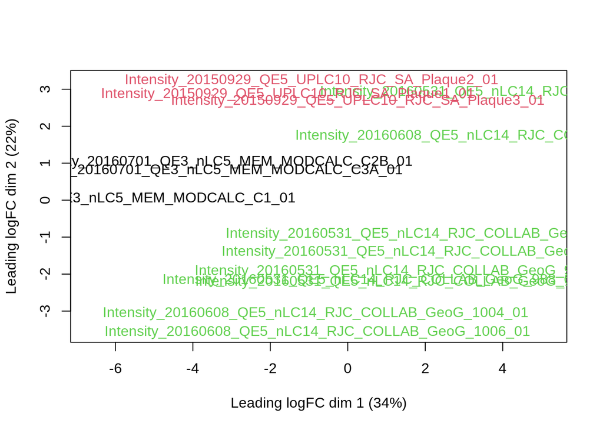

```r
limma::plotMDS(assay(pe[["peptideLog"]], withDimnames = FALSE), col = (colData(pe)$group %>% as.factor %>% as.numeric()))
```

What can you see on this plot?

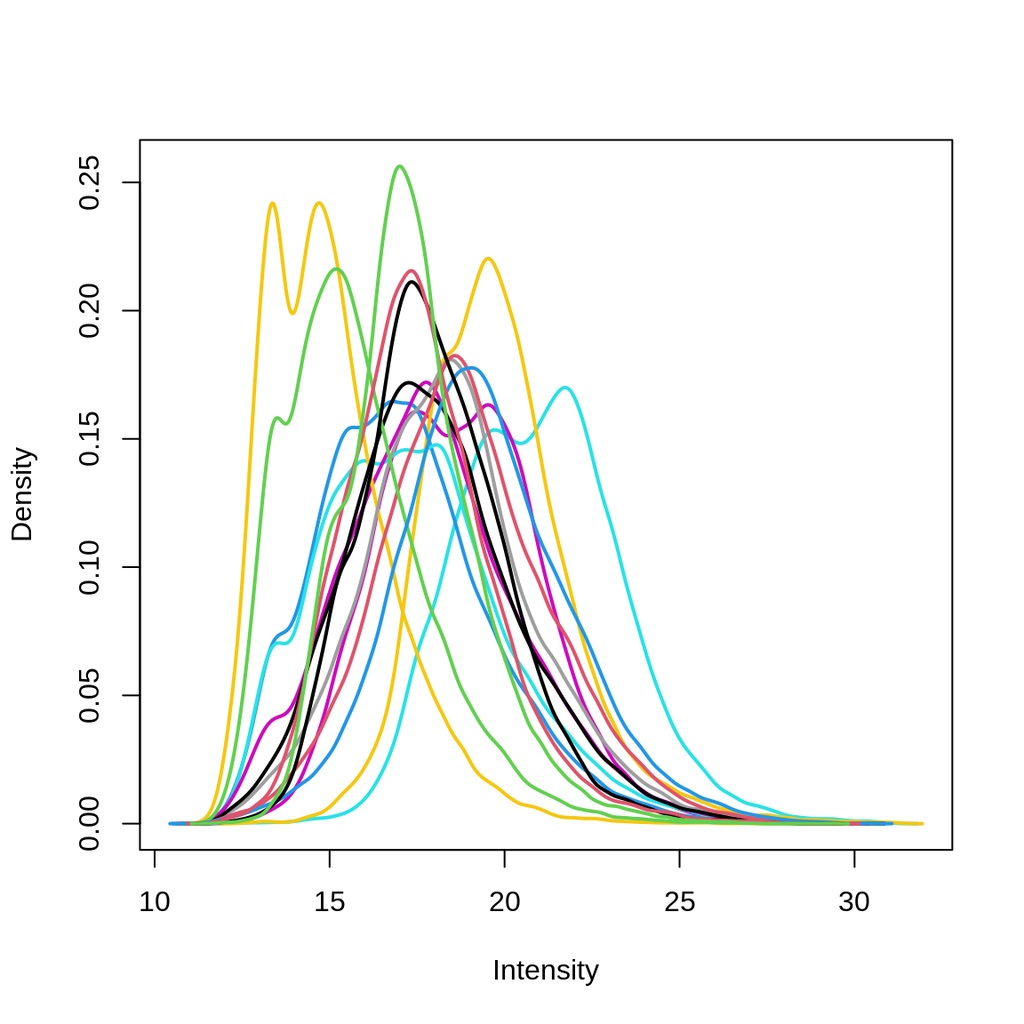

```r
limma::plotDensities(assay(pe[["peptideLog"]]), legend = FALSE)
```

The intensity distributions of the different samples do not coincide, this occurs because of technical variability: differences between the mass spec runs, machines, labs etc.

## Normalization of the data by median centering

```r
pe <- normalize(pe,
                i = "peptideLog",
                name = "peptideNorm",
                method = "center.median")
```

Now visualise the effect of the normalisation. Why is the normalisation necessary?

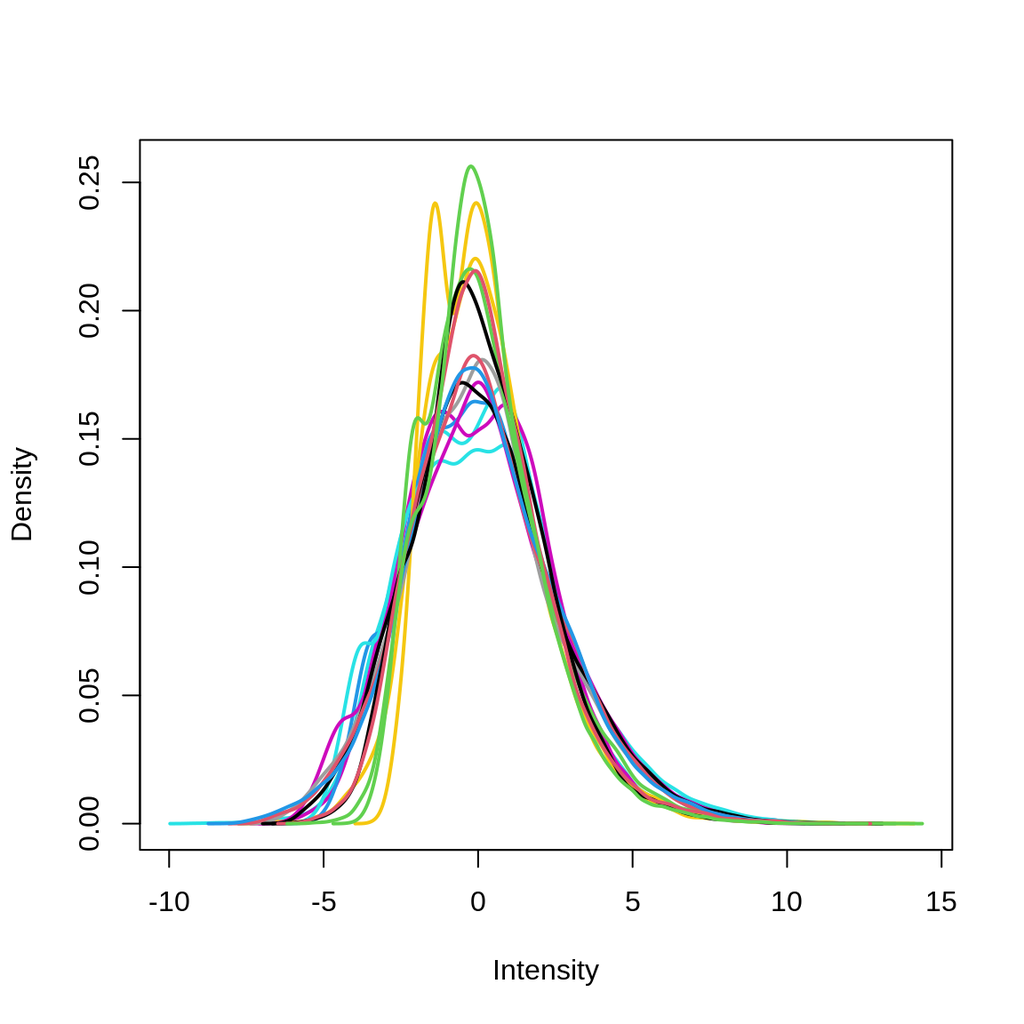

```r
limma::plotDensities(assay(pe[["peptideNorm"]]), legend = FALSE)
```

The intensity distributions need to be put on the same footprint by shifting the intensity peaks to the same locations, so that the different samples are comparable. Upon normalization the marginal distributions of the peptide intensities across samples are much more comparable. We have now done this by median centering (subtraction of the sample median from each intensity that was measured in that sample). However, we still see deviations, this could be cause to try more sophisticated normalisation methods, but this is very dataset dependent and very challenging because of the missingness in the data.

## Summarisation to protein level

Now we want to summarise all peptide intensities from the same protein in a sample into a single protein expression value. These protein expression values will be used in the differential abundance analysis later on. However, there are some difficulties we have to take into account. For example, each peptide (even from the same protein) has different characteristics (different length, mass..) and thus will fly differently through the mass spec, resulting in strong differences in peptide intensities between different peptides.  
Indeed, peptides that do not fly very well through the mass spec will not be picked up as well as other peptides that do, leading to more missingnes for the first set of peptides. For all those different peptides belonging to the same proteins we will now try to find one protein expression value. You could do this by taking the mean or median of all the peptide intensities, but that can introduce biases (eg because of missingness in some peptides). To correct for this, we will use a linear model that will estimate a sample mean, while also correcting for the different peptide characteristics (see below). If you do that, you will correct for the fact that different peptides (even from the same protein) have different characteristics.

how do you do that? by modeling the intensities of sample i en peptide p with sample specific effect and peptide specific effect, than you will have sample average (beta sample) that is corrected for peptide species (addition of beta peptide)

- Mean summarization
  $$y_{ip}=\beta_i^\text{samp} + \epsilon_{ip}$$
- Model based summarization:
  $$y_{ip}=\beta_i^\text{samp} + \beta_p^\text{pep} + \epsilon_{ip}$$

When we compare a mean summarisation method to our model based summarisation, we can clearly see that the model based method has an additional parameter $\beta_p^\text{pep}$, which corrects the sample average ($\beta_i^\text{samp}$) for the peptide specific effect.

We use the standard sumarization in aggregateFeatures, which is robust model based summarization. In short, “robust” statistics try to make the model less sensitive to (minor) deviations in the data.

For more information on robust based summarisation, see the following paper: - https://doi.org/10.1074/mcp.RA119.001624

Some peptides do not have a protein associated, these need to be filtered out in order for the summarisation to work properly.

```r
pe <- filterFeatures(pe, ~Protein.Groups!="")
```

```r
pe <- aggregateFeatures(pe,
    i = "peptideNorm",
    fcol = "Protein.Groups",
    na.rm = TRUE,
    name = "protein")
```

```
## Your quantitative and row data contain missing values. Please read the
## relevant section(s) in the aggregateFeatures manual page regarding the
## effects of missing values on data aggregation.
```

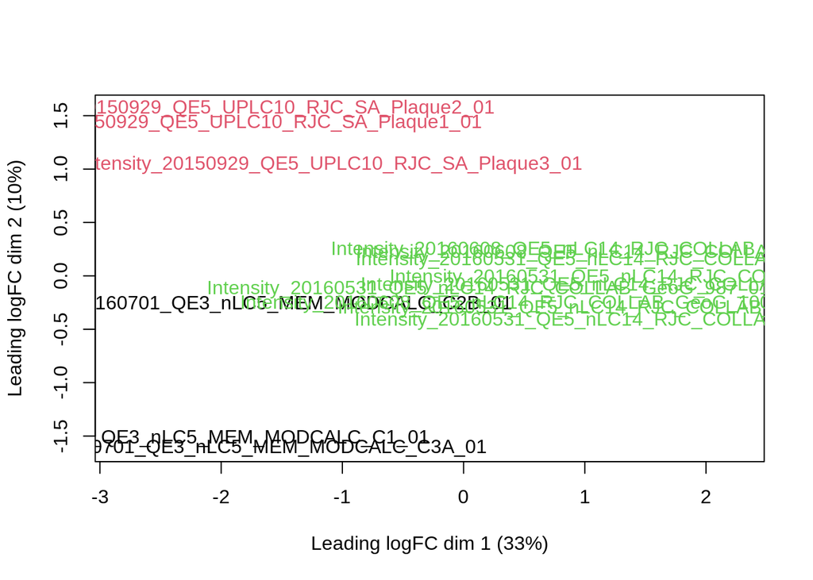

```r
limma::plotMDS(assay(pe[["protein"]], withDimnames = FALSE), col = (colData(pe)$group %>% as.factor %>% as.numeric()))
```

What do you see on this MDS plot?

## Data Analysis

We model the protein level expression values using `msqrob`. By default `msqrob2` estimates the model parameters using robust regression. In short, “robust” statistics try to make the model less sensitive to (minor) deviations in the data. If you want to know more, see: https://doi.org/10.1074/mcp.M115.055897

We will model the data with a different group mean for each of the groups (Tjærby, ModPlaque and ModCalc). The group is incoded in the variable `group` of the colData. We can specify this model by using a formula with the factor group as its predictor: `formula = ~group`.

Note, that a formula always starts with a symbol ‘~’.

We can now choose a reference group, by using the function relevel. If we here choose “Tjærby”, we will be able to compare our other group levels (“ModPlaque” and “ModCalc”) directly to the “Tjærby” group. (see also below)

```r
colData(pe)$group <- relevel(as.factor(colData(pe)$group), ref = "Tjærby")
```

```r
pe <- msqrob(object = pe, i = "protein", formula = ~group)
```

### Inference

```r
getCoef(rowData(pe[["protein"]])$msqrobModels[[2]])
```

```
##    (Intercept)   groupModCalc groupModPlaque
##     -0.2870380     -0.9347516      0.3590487
```

We can also explore the design of the model that we specified using the the package `ExploreModelMatrix`

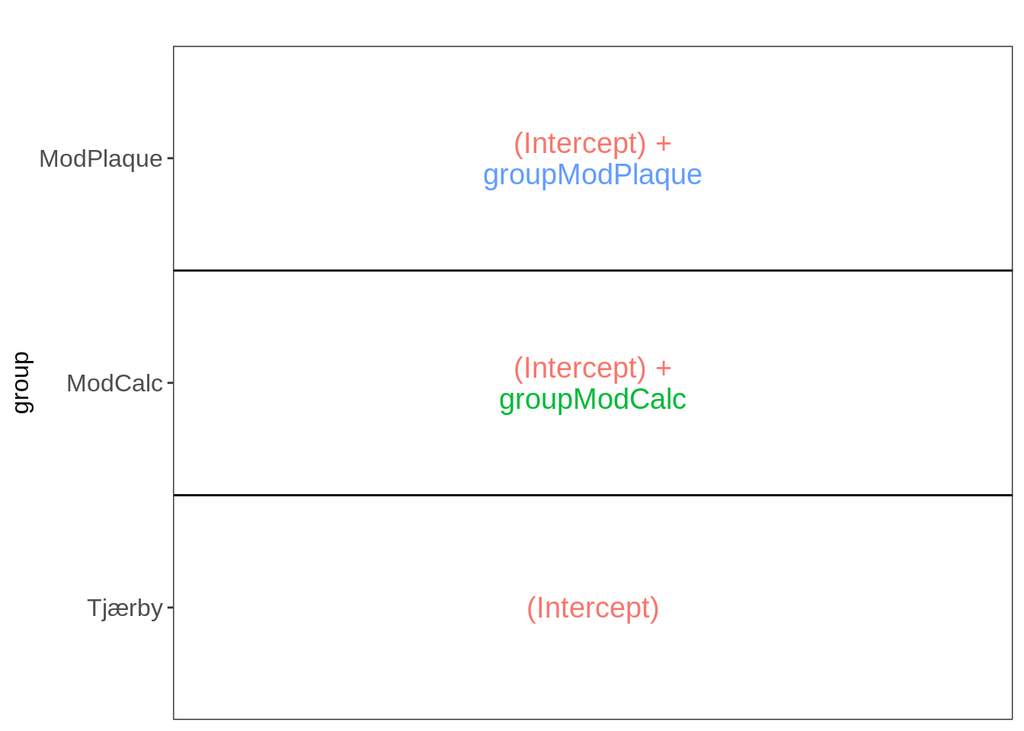

```r
library(ExploreModelMatrix)
VisualizeDesign(colData(pe),~group)$plotlist[[1]]
```

In this example, this is quite simple because we have only one model parameter “group”. As chosen above, Tjærby is the reference class. So the mean log2 expression for samples from Tjærby is ‘(Intercept)’. The mean log2 expression for samples from groupModCalc is ‘(Intercept)+groupModCalc’. Hence, the average log2 fold change between Tjærby and ModCalc is modelled using the parameter ‘groupModCalc’ (Intercept - (Intercept + groupModCalc)) . Thus, we assess the contrast ‘groupModCalc = 0’ (our null hypothesis) with our statistical test. In the same way, the average log2 fold change between Tjærby and ModPlaque is modelled using the parameter ‘groupModPlaque’. Moreover, the average log2 fold change between ModCalc and ModPlaque is modelled using ‘groupModCalc - groupModPlaque’.

Let’s first investigate whether there are proteins differentially expressed between the Tjærby group and the Modern Calculus group. As explained above, to do this, we will test the null hypothesis: groupModCalc=0.

```r
#The first argument is/are the contrast(s) we want to test, the second are the parameternames present in the model
L <- makeContrast("groupModCalc=0", parameterNames = c("groupModCalc", "groupModPlaque"))
#statistical inference, multiple testing correction defaults to the Benjamini-Hochberg procedure
pe <- hypothesisTest(object = pe, i = "protein", contrast = L)
```

### Significance table

We can now assess the proteins that are found as differentially expressed.

```r
rowData(pe[["protein"]])$groupModCalc %>%
  #We only look at the proteins that have an adjusted pvalue smaller than 0.05
  filter(adjPval<0.05)  %>%
  head(20)
```

```
##                               logFC        se       df         t         pval
## A0A075B6N7                 2.352761 0.7156819 16.33734  3.287440 4.536098e-03
## A0A087WV01                 2.248316 0.6186326 17.59371  3.634333 1.956128e-03
## A0A087WV01;Q9YIC0          3.536729 0.7676071 18.86148  4.607473 1.955469e-04
## A0A087X1N8                -6.101451 0.6947231 16.69002 -8.782566 1.159564e-07
## A0A0G2JRN3;P01009         -5.939197 0.7310200 17.53995 -8.124535 2.365584e-07
## A1B002                     4.146889 0.9650806 10.93869  4.296935 1.278530e-03
## A1B937                    -5.503644 1.0371979 17.28213 -5.306262 5.496379e-05
## A1L595                     3.439034 0.4948683 18.18130  6.949392 1.619549e-06
## A3CV28                    -5.590854 1.4035237 10.66282 -3.983441 2.280299e-03
## A4G921                     3.503747 1.0289736 10.25577  3.405090 6.478257e-03
## A4VYX5                     3.818819 0.9981706 15.22537  3.825818 1.613801e-03
## A4XKR2                    -4.189874 1.2835590 14.84230 -3.264263 5.289958e-03
## A5A6I5;ALDOA_RABIT         3.783836 0.7858757 17.68928  4.814803 1.454176e-04
## A5A6I5;ALDOA_RABIT;P05064  3.469423 0.5287438 16.60719  6.561632 5.440415e-06
## A5A6I6;TRFE_HUMAN          3.540599 0.6260926 18.80767  5.655073 1.953642e-05
## A5A6M0                     2.009933 0.4908475 18.86148  4.094822 6.251047e-04
## A5A8V7;Q91291              8.580149 1.0442468 10.64712  8.216591 6.248710e-06
## A5FIJ2;cot326_c_76_2545    4.718219 0.9628973 18.77381  4.900023 1.027329e-04
## A5N4N1                     3.952116 0.8780282 16.84815  4.501126 3.215925e-04
## A5UMI1                    -5.088391 1.2035048 10.71102 -4.227978 1.502707e-03
##                                adjPval
## A0A075B6N7                3.763898e-02
## A0A087WV01                2.208637e-02
## A0A087WV01;Q9YIC0         5.326844e-03
## A0A087X1N8                6.051638e-05
## A0A0G2JRN3;P01009         8.949890e-05
## A1B002                    1.715787e-02
## A1B937                    2.589711e-03
## A1L595                    2.857584e-04
## A3CV28                    2.445334e-02
## A4G921                    4.684892e-02
## A4VYX5                    1.951725e-02
## A4XKR2                    4.069932e-02
## A5A6I5;ALDOA_RABIT        4.502730e-03
## A5A6I5;ALDOA_RABIT;P05064 6.295516e-04
## A5A6I6;TRFE_HUMAN         1.433790e-03
## A5A6M0                    1.083438e-02
## A5A8V7;Q91291             7.072335e-04
## A5FIJ2;cot326_c_76_2545   3.644704e-03
## A5N4N1                    7.144219e-03
## A5UMI1                    1.882137e-02
```

### Plots

#### Volcano-plot

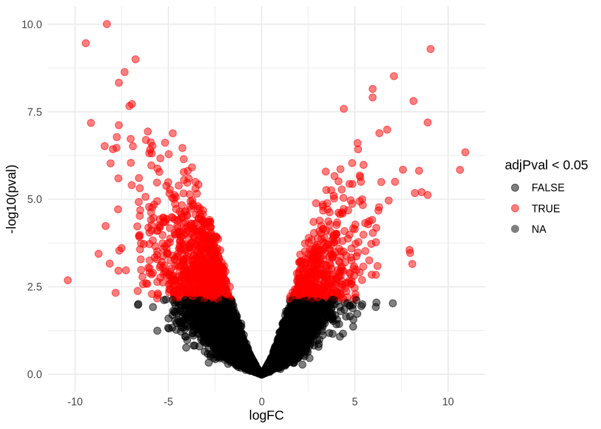

```r
volcano <- ggplot(rowData(pe[["protein"]])$groupModCalc,
                  aes(x = logFC, y = -log10(pval), color = adjPval < 0.05)) +
  geom_point(cex = 2.5) +
  scale_color_manual(values = alpha(c("black", "red"), 0.5)) + theme_minimal()
volcano
```

#### Heatmap

We first select the names of the proteins that were declared signficant.

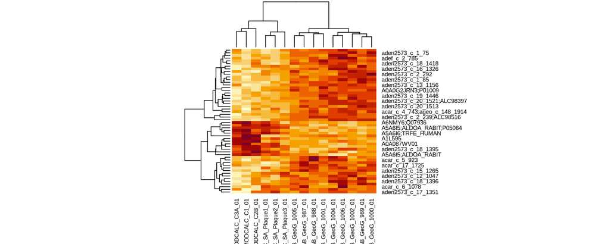

```r
sigNames <- rowData(pe[["protein"]])$groupModCalc %>%
  rownames_to_column("protein") %>%
  filter(adjPval<0.05) %>%
  head(100) %>%
  pull(protein)
heatmap(MSnbase::filterNA(assay(pe[["protein"]])[sigNames, ]), cexCol = 0.7, cexRow = 0.7)
```

### Exercise: inference

If you have completed all of the above and you want an extra challenge, try to find differential proteins between groupModPlaque and groupTjærby and between groupModPlaque and groupModCalc.

# Acknowledgements

Parts of this workshop were inspired by the QFeatures tutorial of Laurent Gatto (http://www.bioconductor.org/packages/release/bioc/vignettes/QFeatures/inst/doc/Processing.html) and by the proteomics data analysis workshops by Lieven Clement (https://statomics.github.io/PDA/)

Special thanks to Kevin Velghe for setting up the binder for this workshop